# Circadian PER2 Expression in Myopic vs Non-Myopic Chick Retina at ZT08

He Li | Master of Science in Computational Biology

2025-04-24

# Introduction

Circadian transcription factors coordinate photoreceptor renewal, neurotransmitter release, and ocular-growth signals in the retina (Iuvone et al., 2005).  
**PER2** peaks near mid-day in chick retina, modulates dopamine- and retinoic-acid pathways relevant to axial elongation, and its diurnal expression profile is shown to be altered during form-deprivation myopia progression (Stone et al., 2020, 2024).

In this project, I hypothesize that **PER2** transcript levels differ between occluded (myopic) and untreated retinas at Zeitgeber Time 08 (ZT08) for females chicks using publicly available RNA-seq data (SRA SRP494275, HiSeq 4000, 2024-03-09). I analyze these libraries with a reproducible DESeq2 pipeline that emphasizes quality control and report whether a ZT08 snapshot suffices to reveal circadian dysregulation associated with experimental myopia.

# Result

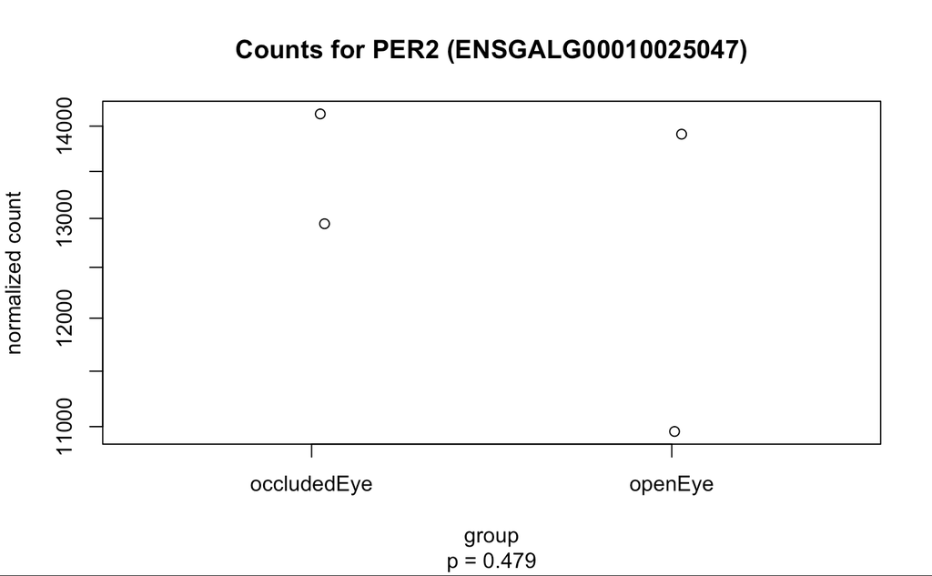

Differential-Expression Analyses

# Methods

### Data

| Run Accession | Tissue | Time (ZT) | Condition |  |  |  |  |
| --- | --- | --- | --- | --- | --- | --- | --- |
| **SRR28279786** | Retina | 08 | Open |  |  |  |  |
| **SRR28279788** | Retina | 08 | Occluded |  |  |  |  |
| **SRR28279790** | Retina | 08 | Open |  |  |  |  |
| **SRR28279792** | Retina | 08 | Occluded |  |  |  |  |

Data are from SRA study **SRP494275** (BioProject PRJNA1086001) generated on 2024-03-09 by the New England College of Optometry using an Illumina HiSeq 4000 platform. The libraries were constructed using the Illumina TruSeq Stranded mRNA kit, which incorporates a poly(A)‐selection step, resulting in 2 × 150 bp paired‐end reads. The samples above are used. The samples are downloaded using fastq-dump, then renamed and unzipped.

### Raw-read quality assessment

The sequencing output for the four SRR runs was first inspected with **FastQC**.

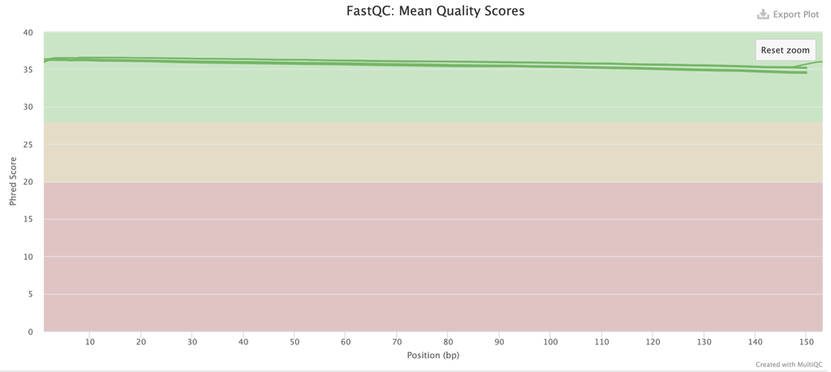

Figure 1: Per‐base quality scores across all samples

The FastQC report for all four libraries shows consistently high per-base quality: median Phred scores remain above thirty (Q ≥ 30) from base 1 through the read tail, with no visible drop-off or nucleotide-specific spikes.

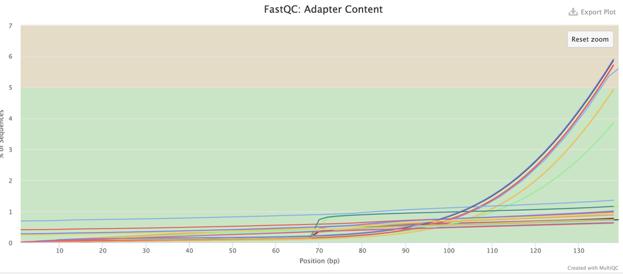

Figure 2: Adapter Content

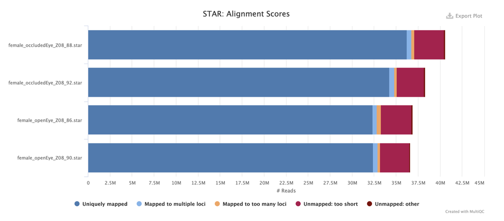

Figure 3: Alignment Scores

All four samples exhibit very similar STAR alignment profiles: about 85% of reads map uniquely to the Gallus gallus reference, < 5 % align to multiple loci, and the unmapped fraction remains below 10 %. Such high unique-mapping rates, with little multimapping or dropout, indicate well-complexed sample and accurate genome indexing.

[figure not shown]

Figure 4: Feature Counts

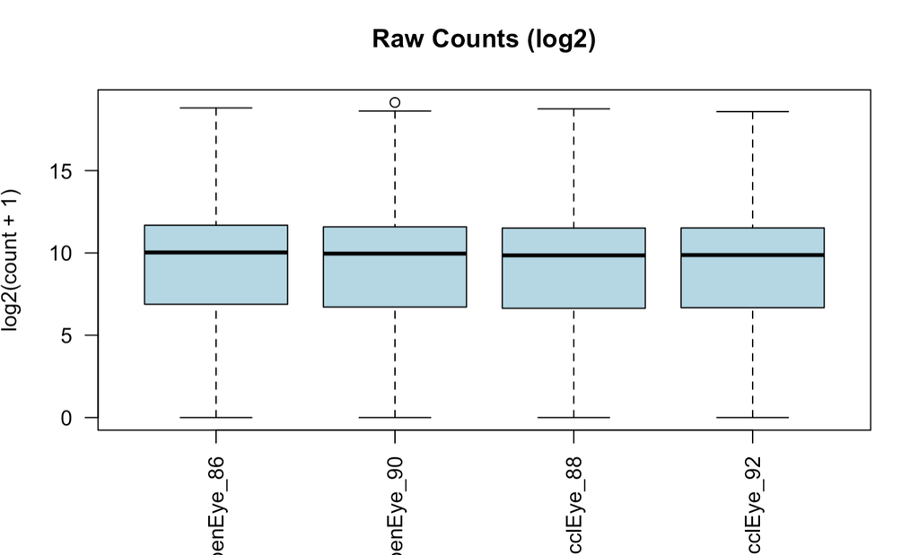

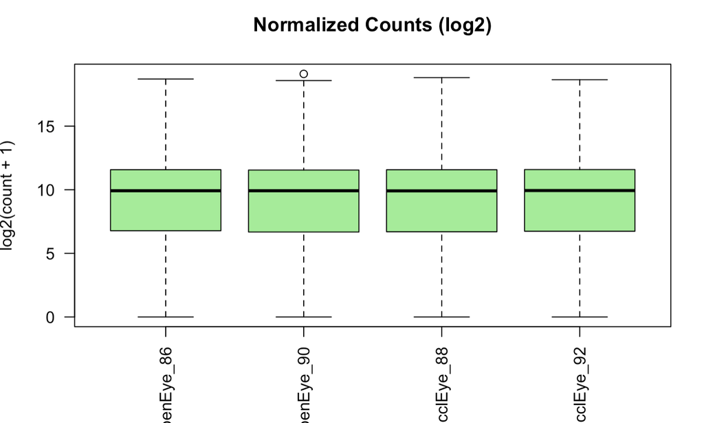

Figure 5: Counts Normalization

The counts are mostly consistent across samples. A sample-wise normalization is conducted but the effect is minimal.

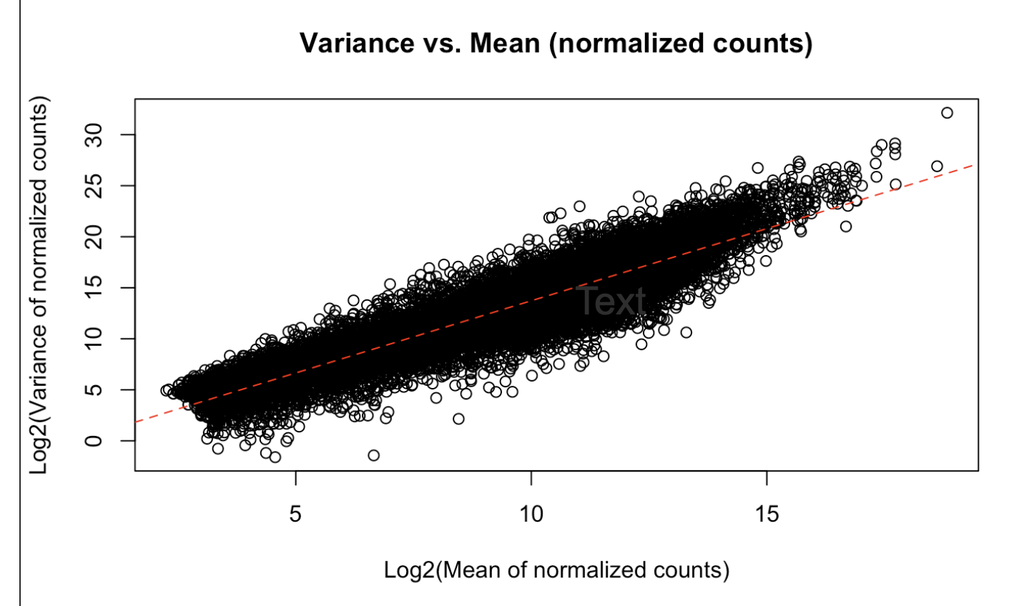

Figure 6: Variance vs. Mean (normalized counts)

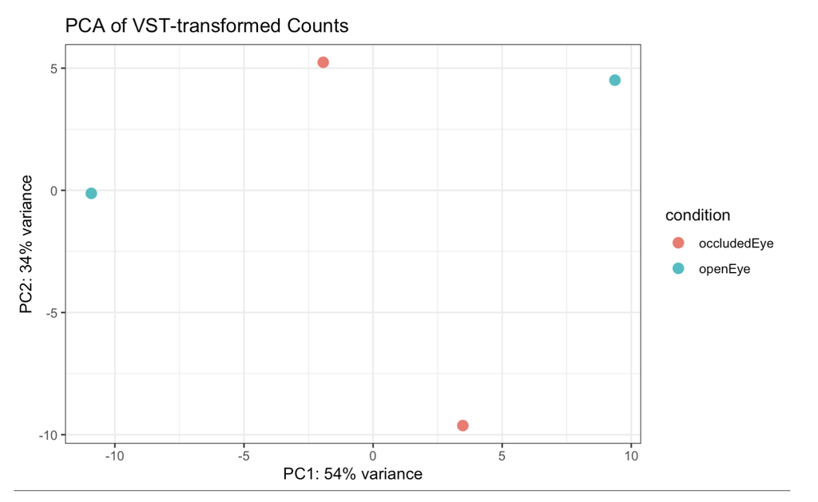

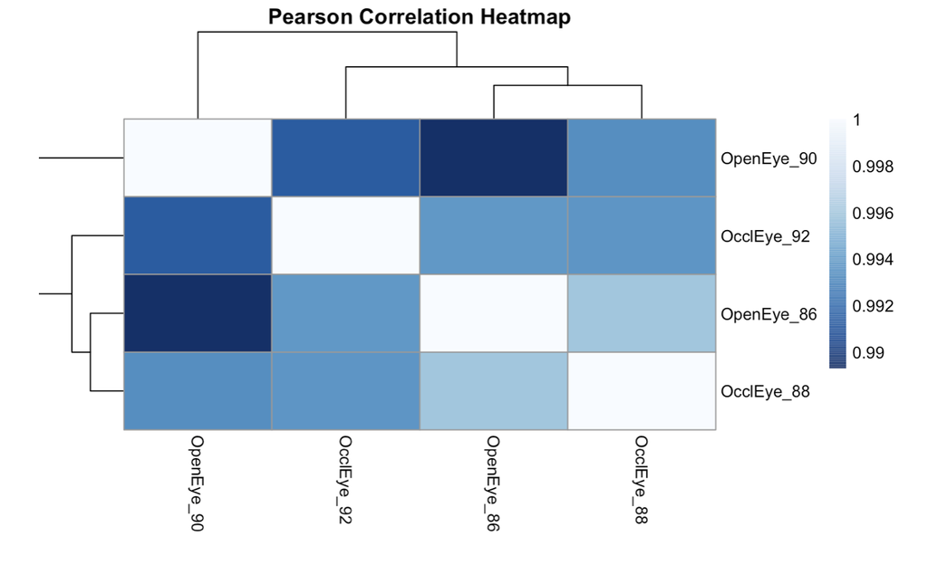

Figure 7: PCA and Heatmap

The PCA and Pearson correlation heatmap reveal that our samples do not cluster by condition, and replicate agreement is weaker than expected. Both shows no clear separation of OcclEye vs. OpenEye, with poor replicate concordance and lack of biological clustering.

# Discussion

The study was constrained by a very small sample size (n = 2 per condition), which limited statistical power and precluded clear clustering of OpenEye versus OcclEye samples in both PCA and correlation analyses. Consequently, the differential expression analysis for **PER2** at ZT08 did not reach significance (p = 0.479). Another limitation is that the chosen reference genome (GRCg7b) is not yet supported in IGV, restricting our ability to inspect read alignments for strand‐specific artifacts or novel splice variants. Future work should expand sampling and leverage an IGV‐compatible annotation to validate and visualize strandness and transcript structure in candidate genes.

# Data summary

[output not shown]

# References

Iuvone, P. M., Tosini, G., Pozdeyev, N., Haque, R., Shaikh, A. U., & Rahman, S. (2005). Circadian clocks, clock networks, arylalkylamine n-acetyltransferase, and melatonin in the retina. *Progress in Retinal and Eye Research*, *24*(4), 433–456. https://doi.org/10.1016/j.preteyeres.2004.12.001

Stone, R. A., Wei, W., Sarfare, S., McGeehan, B., Engelhart, K. C., Khurana, T. S., Iuvone, P. M., & Nickla, D. L. (2024). Diurnal gene expression patterns in retina and choroid distinguish myopia progression from myopia onset. *PLOS ONE*, *19*(3), e0282799. https://doi.org/10.1371/journal.pone.0282799

Stone, R. A., Wei, W., Sarfare, S., McGeehan, B., Engelhart, K. C., Khurana, T. S., Maguire, M. G., Iuvone, P. M., & Nickla, D. L. (2020). Visual image quality impacts circadian rhythm‐related gene expression in retina and choroid. *Investigative Ophthalmology & Visual Science*, *61*(5), 13. https://doi.org/10.1167/iovs.61.5.13